# STAT 652 Sec 1 - Project

Yen Tran

02/08/2019

## Abstract

This project is to develop the best classification model to classify loan default for Lending Club. Applying different Machine Learning algorithms, the best model is selected based on the highest AUC value between the predicted probability and the observed label. The winning model is Logistic Regression model.

## Introduction

#### Business Understanding

Lending Club is the world’s largest peer-to-peer lending platform. It operates an online lending platforms that enables borrowers to obtain a loan, and investors to purchases notes backed by payments made on loans. Lending Club enables borrowers to create unsecured personal loans between 1,000 and 40,000 dollars.

#### Problem Statement

How to classify or detect which loan will more likely to default based on the borrower’s credit history?

#### Data

I downloaded the data from [Lending Club database](https://www.lendingclub.com/info/download-data.action) for data from 2012-2015. As the goal is to build classification model to classify whether a borrower, who already borrowed the loan, will repay a loan or not based on borrower’s credit history.

The objective is to predict whether a borrower will default the loan, loan_status will be either Fully Paid or Charged Off, with binary of 0 and 1 respectively.

#### Model applied

1. kNN
2. C5.0
3. Naive Bayes
4. Logistic Regression with LASSO
5. Random Forest
6. Bagged Tree
7. GBM - Boosted Tree

#### Evaluation Approach

The are under the ROC curve (AUC) is used to compare model performances, where the ROC plots True Positive Rate versus False Positive Rate. Below is the summary table of evaluation methods:

| Model | AUC | Accuracy | Kappa |
| --- | --- | --- | --- |
| kNN | 0.213 | 0.9111 | 0.6253 |
| C5.0 Tree | 0.998 | 0.9972 | 0.9905 |
| Naive Bayes | 0.903 | 0.7378 | 0.4081 |
| Logistic Regression | 1.000 | 0.9997 | 0.9991 |
| Random Forest | 0.999 | 0.9919 | 0.9721 |
| Bagged Trees | 0.997 | 0.9964 | 0.9877 |
| GBM | 0.999 | 0.9876 | 0.9566 |

## Conclusions

The logistic regression model performs better than other algorithms with highest area under the ROC curve between the predicted probability and the observed label.

## Code

### Step 1a: Download data

```r
#Unzip data files
unzip("./data/2012-2013.zip",exdir="./data")
unzip("./data/2014.zip",exdir="./data")
```

```r
#Clean up data directory
fn <- "./data/2012-2013.zip"
if (file.exists(fn)) file.remove(fn)
fn <- "./data/2014.zip"
if (file.exists(fn)) file.remove(fn)
```

```r
#Read the.csv files
Loan_1213 <- read.csv(file="./data/LoanStats3b.csv", skip = 1, na.strings=c(""))
Loan_14 <- read.csv(file="./data/LoanStats3c.csv", skip = 1, na.strings=c(""))
```

```r
library(dplyr)
#Removing the last two rows, empty rows due to importing error
Loan_1213 <- Loan_1213[1:(nrow(Loan_1213)-2),]
Loan_14 <- Loan_14[1:(nrow(Loan_1213)-2),]

Loan_1213 %>% group_by(issue_d) %>% summarise(count = n())
Loan_14 %>% group_by(issue_d) %>% summarise(count = n())

Loan_14 %>% group_by(member_id) %>% summarise(count = n()) %>% arrange(count)
```

```r
#Merging data from 2012 - 2014, converting same data type for both files.
class(Loan_1213$hardship_dpd)
class(Loan_14$hardship_dpd)

Loan_1213$hardship_dpd <- as.numeric(Loan_1213$hardship_dpd)
class(Loan_1213$hardship_dpd)

Loan_merged <- bind_rows(Loan_1213, Loan_14)

saveRDS(Loan_merged, file = "Loan_merged")
```

### Step 1b: Load data

```r
library(dplyr)
Loan <- readRDS(file="Loan_merged")
```

### Step 2: Explore and prepare data for analysis

```r
#Explore data table structure
dim(Loan)
```

```
[1] 376360    145
```

```r
head(Loan)
```

|  | id | member_id | loan_amnt | funded_amnt | funded_amnt_inv | term | int_rate | installment | grade | sub_grade | emp_title | emp_length | home_ownership | annual_inc | verification_status | issue_d | loan_status | pymnt_plan | url | desc | purpose | title | zip_code | addr_state | dti | delinq_2yrs | earliest_cr_line | inq_last_6mths | mths_since_last_delinq | … |
| --- | --- | --- | --- | --- | --- | --- | --- | --- | --- | --- | --- | --- | --- | --- | --- | --- | --- | --- | --- | --- | --- | --- | --- | --- | --- | --- | --- | --- | --- | --- |
| 1 | NA | NA | 7550 | 7550 | 7550 | 36 months | 16.24% | 266.34 | C | C5 | Special Order Fulfillment Clerk | 3 years | RENT | 28000 | Not Verified | Dec-2013 | Fully Paid | n | NA | NA | debt_consolidation | Debt consolidation | 951xx | CA | 8.40 | 0 | Oct-2010 | 0 | NA | … |
| 2 | NA | NA | 3000 | 3000 | 3000 | 36 months | 12.85% | 100.87 | B | B4 | Auditor | 10+ years | RENT | 25000 | Verified | Dec-2013 | Fully Paid | n | NA | NA | debt_consolidation | debt | 322xx | FL | 24.68 | 0 | May-1991 | 0 | 58 | … |
| 3 | NA | NA | 20800 | 20800 | 20800 | 36 months | 13.53% | 706.16 | B | B5 | Operations Manager | 10+ years | RENT | 81500 | Verified | Dec-2013 | Fully Paid | n | NA | Borrower added on 12/31/13 > My goal is to purchase a home. I am consolidating my debt to lower interest rate to pay off debt faster. My goal is targeted for February 2015. | debt_consolidation | Reducing Debt to Purchase Home | 100xx | NY | 16.73 | 0 | Jun-1998 | 2 | 64 | … |
| 4 | NA | NA | 4800 | 4800 | 4800 | 36 months | 10.99% | 157.13 | B | B2 | Surgical Technician | 2 years | MORTGAGE | 39600 | Source Verified | Dec-2013 | Fully Paid | n | NA | Borrower added on 12/31/13 > Just bought a house, and would like a little extra funds to improve aspects of the house such as, duct work, electrical outlets, backyard, and other minor areas. | home_improvement | For The House | 782xx | TX | 2.49 | 0 | Aug-1995 | 2 | NA | … |
| 5 | NA | NA | 14000 | 14000 | 14000 | 36 months | 12.85% | 470.71 | B | B4 | Assistant Director - Human Resources | 4 years | RENT | 88000 | Not Verified | Dec-2013 | Fully Paid | n | NA | NA | debt_consolidation | Debt consolidation | 282xx | NC | 10.02 | 1 | Jun-1988 | 0 | 16 | … |
| 6 | NA | NA | 15000 | 15000 | 15000 | 36 months | 14.47% | 516.10 | C | C2 | building maint. mgr. | 10+ years | RENT | 98000 | Not Verified | Dec-2013 | Fully Paid | n | NA | Borrower added on 12/31/13 > just to have one payment each month. | debt_consolidation | pay off | 117xx | NY | 6.15 | 0 | Jul-1992 | 2 | NA | … |

```r
tail(Loan)
```

|  | id | member_id | loan_amnt | funded_amnt | funded_amnt_inv | term | int_rate | installment | grade | sub_grade | emp_title | emp_length | home_ownership | annual_inc | verification_status | issue_d | loan_status | pymnt_plan | url | desc | purpose | title | zip_code | addr_state | dti | delinq_2yrs | earliest_cr_line | inq_last_6mths | mths_since_last_delinq | … |
| --- | --- | --- | --- | --- | --- | --- | --- | --- | --- | --- | --- | --- | --- | --- | --- | --- | --- | --- | --- | --- | --- | --- | --- | --- | --- | --- | --- | --- | --- | --- |
| 376355 | NA | NA | 14000 | 14000 | 14000 | 36 months | 14.64% | 482.86 | C | C3 | General Manager | 6 years | RENT | 90000 | Source Verified | Mar-2014 | Charged Off | n | NA | NA | credit_card | Credit card refinancing | 891xx | NV | 7.64 | 0 | Jul-2003 | 1 | 61 | … |
| 376356 | NA | NA | 12000 | 12000 | 12000 | 36 months | 9.67% | 385.35 | B | B1 | foreman | 6 years | MORTGAGE | 53000 | Not Verified | Apr-2014 | Charged Off | n | NA | NA | credit_card | Credit card refinancing | 338xx | FL | 23.80 | 2 | Apr-2003 | 0 | 9 | … |
| 376357 | NA | NA | 10000 | 10000 | 10000 | 36 months | 11.99% | 332.10 | B | B3 | Business Development Analyst | 2 years | RENT | 60000 | Verified | Mar-2014 | Fully Paid | n | NA | NA | credit_card | Credit card refinancing | 606xx | IL | 6.13 | 0 | Oct-2007 | 0 | NA | … |
| 376358 | NA | NA | 30000 | 30000 | 30000 | 36 months | 13.65% | 1020.24 | C | C1 | Principal | 6 years | MORTGAGE | 78000 | Verified | Mar-2014 | Fully Paid | n | NA | NA | credit_card | Credit card refinancing | 310xx | GA | 31.94 | 0 | Aug-1989 | 0 | 46 | … |
| 376359 | NA | NA | 20000 | 20000 | 20000 | 60 months | 14.64% | 472.03 | C | C3 | Carpenter | 10+ years | MORTGAGE | 70000 | Verified | Mar-2014 | Fully Paid | n | NA | NA | debt_consolidation | Debt consolidation | 481xx | MI | 24.58 | 0 | Dec-1994 | 2 | NA | … |
| 376360 | NA | NA | 13300 | 13300 | 13300 | 36 months | 10.99% | 435.37 | B | B2 | Regional Sales Manager | < 1 year | MORTGAGE | 72000 | Source Verified | Mar-2014 | Fully Paid | n | NA | NA | home_improvement | Home improvement | 633xx | MO | 11.75 | 0 | Sep-1993 | 1 | NA | … |

```r
str(Loan)
```

```
'data.frame':   376360 obs. of  145 variables:
 $ id                                        : chr  NA NA NA NA ...
 $ member_id                                 : logi  NA NA NA NA NA NA ...
 $ loan_amnt                                 : int  7550 3000 20800 4800 14000 15000 11100 12000 9750 15000 ...
 $ funded_amnt                               : int  7550 3000 20800 4800 14000 15000 11100 12000 9750 15000 ...
 $ funded_amnt_inv                           : num  7550 3000 20800 4800 14000 15000 11100 12000 9750 15000 ...
 $ term                                      : Factor w/ 2 levels " 36 months"," 60 months": 1 1 1 1 1 1 1 1 1 1 ...
 $ int_rate                                  : chr  " 16.24%" " 12.85%" " 13.53%" " 10.99%" ...
 $ installment                               : num  266 101 706 157 471 ...
 $ grade                                     : Factor w/ 7 levels "A","B","C","D",..: 3 2 2 2 2 3 3 2 3 1 ...
 $ sub_grade                                 : Factor w/ 35 levels "A1","A2","A3",..: 15 9 10 7 9 12 13 10 11 5 ...
 $ emp_title                                 : chr  "Special Order Fulfillment Clerk" "Auditor" "Operations Manager" "Surgical Technician" ...
 $ emp_length                                : Factor w/ 12 levels "< 1 year","1 year",..: 5 3 3 4 6 3 3 3 2 4 ...
 $ home_ownership                            : chr  "RENT" "RENT" "RENT" "MORTGAGE" ...
 $ annual_inc                                : num  28000 25000 81500 39600 88000 98000 90000 40000 26000 63000 ...
```

[output cut: 86 more lines]

```r
#Response variable
table(Loan$loan_status)
```

```
       Charged Off            Current            Default         Fully Paid
             62855              12860                  1             299845
   In Grace Period  Late (16-30 days) Late (31-120 days)
               316                108                375
```

```r
#Get the indices of those loans categorized as Charged Off, Fully Paid, or Default
indx <- which(Loan[["loan_status"]] == c("Charged Off", "Fully Paid"))
length(indx)
Loan <- Loan[indx,]
```

```r
#Converting response variable as a factor of binary outcomes
Loan$loan_status <- ifelse(Loan$loan_status == "Fully Paid", 0, 1)
Loan$loan_status <- as.factor(Loan$loan_status)
table(Loan$loan_status)
```

```r
## Drop columns that have more than half number of NA values
# specify columns that have no information (including ID columns)
idx <- which(sapply(Loan,function(x) sum(is.na(x))) > (nrow(Loan)*0.5))
Loan_dropped <- Loan[,-idx]
# Remove rows that contains NAs
Loan_dropped <- na.omit(Loan_dropped)
dim(Loan_dropped)
```

```
[1] 134289     87
```

```r
head(Loan_dropped)
```

|  | loan_amnt | funded_amnt | funded_amnt_inv | term | int_rate | installment | grade | sub_grade | emp_title | emp_length | home_ownership | annual_inc | verification_status | issue_d | loan_status | pymnt_plan | purpose | title | zip_code | addr_state | dti | delinq_2yrs | earliest_cr_line | inq_last_6mths | open_acc | pub_rec | revol_bal | revol_util | total_acc | … |
| --- | --- | --- | --- | --- | --- | --- | --- | --- | --- | --- | --- | --- | --- | --- | --- | --- | --- | --- | --- | --- | --- | --- | --- | --- | --- | --- | --- | --- | --- | --- |
| 2 | 3000 | 3000 | 3000 | 36 months | 12.85% | 100.87 | B | B4 | Auditor | 10+ years | RENT | 25000 | Verified | Dec-2013 | 0 | n | debt_consolidation | debt | 322xx | FL | 24.68 | 0 | May-1991 | 0 | 5 | 2 | 2875 | 54.2% | 26 | … |
| 4 | 4800 | 4800 | 4800 | 36 months | 10.99% | 157.13 | B | B2 | Surgical Technician | 2 years | MORTGAGE | 39600 | Source Verified | Dec-2013 | 0 | n | home_improvement | For The House | 782xx | TX | 2.49 | 0 | Aug-1995 | 2 | 3 | 0 | 4136 | 16.1% | 8 | … |
| 6 | 15000 | 15000 | 15000 | 36 months | 14.47% | 516.10 | C | C2 | building maint. mgr. | 10+ years | RENT | 98000 | Not Verified | Dec-2013 | 0 | n | debt_consolidation | pay off | 117xx | NY | 6.15 | 0 | Jul-1992 | 2 | 16 | 0 | 5749 | 22.3% | 16 | … |
| 8 | 12000 | 12000 | 12000 | 36 months | 13.53% | 407.40 | B | B5 | On road manager | 10+ years | RENT | 40000 | Source Verified | Dec-2013 | 0 | n | debt_consolidation | Debt consolidation | 871xx | NM | 16.94 | 0 | Oct-1998 | 0 | 7 | 2 | 5572 | 68.8% | 32 | … |
| 10 | 15000 | 15000 | 15000 | 36 months | 8.90% | 476.30 | A | A5 | aircraft maintenance engineer | 2 years | MORTGAGE | 63000 | Not Verified | Dec-2013 | 0 | n | debt_consolidation | Pay off | 334xx | FL | 16.51 | 0 | Mar-1998 | 0 | 8 | 0 | 11431 | 74.2% | 29 | … |
| 14 | 24000 | 24000 | 24000 | 36 months | 13.53% | 814.80 | B | B5 | driver | 10+ years | MORTGAGE | 100000 | Verified | Dec-2013 | 0 | n | credit_card | credit card | 493xx | MI | 22.18 | 0 | Jan-1989 | 0 | 14 | 0 | 21617 | 76.7% | 39 | … |

```r
#Converting interest rate variable to numeric
Loan_dropped$int_rate <- as.numeric(sub("%","",Loan_dropped$int_rate))/100
Loan_dropped$revol_util <- as.numeric(sub("%","",Loan_dropped$revol_util))/100
Loan_dropped$emp_length <- as.factor(Loan_dropped$emp_length)
Loan_dropped$home_ownership <- as.factor(Loan_dropped$home_ownership)
```

```r
#Drop character variables
Loan_dropped <- Loan_dropped[, !sapply(Loan_dropped, is.character)]
#Drop variables that are caused by default status
Loan_dropped <- Loan_dropped[ , !names(Loan_dropped) %in% c('recoveries', 'collection_recovery_fee', 'debt_settlement_flag', 'settlement_status', 'hardship_loan_status', 'hardship_type')]
#Remove all zeros columns
Loan_dropped <- Loan_dropped[ , !names(Loan_dropped) %in% c("out_prncp","out_prncp_inv","policy_code","next_pymnt_d", "application_type", "disbursement_method")]
#Remove categorical variable sub_grade to avoid new categories in test data
Loan_dropped <- Loan_dropped[, !names(Loan_dropped)== 'sub_grade']
```

```r
dim(Loan_dropped)
```

```
[1] 134289     68
```

```r
summary(Loan_dropped)
```

```
   loan_amnt      funded_amnt    funded_amnt_inv         term          int_rate
 Min.   : 1000   Min.   : 1000   Min.   : 1000    36 months:98161   Min.   :0.0600
 1st Qu.: 8400   1st Qu.: 8400   1st Qu.: 8400    60 months:36128   1st Qu.:0.1099
 Median :13000   Median :13000   Median :13000                      Median :0.1398
 Mean   :14791   Mean   :14791   Mean   :14784                      Mean   :0.1401
 3rd Qu.:20000   3rd Qu.:20000   3rd Qu.:20000                      3rd Qu.:0.1699
 Max.   :35000   Max.   :35000   Max.   :35000                      Max.   :0.2606

  installment      grade         emp_length     home_ownership    annual_inc
 Min.   :  27.85   A:20103   10+ years:46688   MORTGAGE:71789   Min.   :   4000
 1st Qu.: 273.11   B:39551   2 years  :12297   NONE    :   16   1st Qu.:  48000
 Median : 398.38   C:37017   3 years  :10726   OTHER   :   15   Median :  65000
 Mean   : 449.46   D:22270   < 1 year :10268   OWN     :11483   Mean   :  75954
 3rd Qu.: 587.34   E:10355   5 years  : 8936   RENT    :50986   3rd Qu.:  90000
 Max.   :1408.13   F: 4054   1 year   : 8609                    Max.   :7500000
                   G:  939   (Other)  :36765
      verification_status loan_status               purpose           dti
 Not Verified   :42807    0:110817    debt_consolidation:82302   Min.   : 0.00
 Source Verified:45109    1: 23472    credit_card       :30598   1st Qu.:12.20
 Verified       :46373                home_improvement  : 7430   Median :17.66
                                      other             : 5823   Mean   :18.03
                                      major_purchase    : 2310   3rd Qu.:23.61
                                      small_business    : 1274   Max.   :39.99
                                      (Other)           : 4552
  delinq_2yrs      inq_last_6mths      open_acc        pub_rec          revol_bal
 Min.   : 0.0000   Min.   :0.0000   Min.   : 1.00   Min.   : 0.0000   Min.   :      0
 1st Qu.: 0.0000   1st Qu.:0.0000   1st Qu.: 8.00   1st Qu.: 0.0000   1st Qu.:   6858
 Median : 0.0000   Median :1.0000   Median :11.00   Median : 0.0000   Median :  12241
 Mean   : 0.3059   Mean   :0.8493   Mean   :11.87   Mean   : 0.1682   Mean   :  16796
 3rd Qu.: 0.0000   3rd Qu.:1.0000   3rd Qu.:14.00   3rd Qu.: 0.0000   3rd Qu.:  20916
 Max.   :21.0000   Max.   :8.0000   Max.   :84.00   Max.   :54.0000   Max.   :2568995

   revol_util       total_acc      initial_list_status  total_pymnt       total_pymnt_inv
 Min.   :0.0000   Min.   :  3.00   f:79504             Min.   :   35.79   Min.   :   35.79
 1st Qu.:0.4010   1st Qu.: 18.00   w:54785             1st Qu.: 8395.40   1st Qu.: 8392.49
 Median :0.5750   Median : 25.00                       Median :13836.67   Median :13829.10
 Mean   :0.5648   Mean   : 26.41                       Mean   :16380.10   Mean   :16373.08
 3rd Qu.:0.7410   3rd Qu.: 33.00                       3rd Qu.:22280.60   3rd Qu.:22271.03
 Max.   :1.5070   Max.   :156.00                       Max.   :62862.51   Max.   :62862.51

```

[output cut: 72 more lines]

```
 pub_rec_bankruptcies   tax_liens        tot_hi_cred_lim   total_bal_ex_mort
 Min.   :0.000        Min.   : 0.00000   Min.   :    500   Min.   :      0
 1st Qu.:0.000        1st Qu.: 0.00000   1st Qu.:  51614   1st Qu.:  22411
 Median :0.000        Median : 0.00000   Median : 123621   Median :  37733
 Mean   :0.112        Mean   : 0.03613   Mean   : 177609   Mean   :  49108
 3rd Qu.:0.000        3rd Qu.: 0.00000   3rd Qu.: 257112   3rd Qu.:  61072
 Max.   :7.000        Max.   :53.00000   Max.   :9999999   Max.   :2644442

 total_bc_limit   total_il_high_credit_limit
 Min.   :   100   Min.   :      0
 1st Qu.:  7559   1st Qu.:  15239
 Median : 14500   Median :  30772
 Mean   : 20462   Mean   :  40546
 3rd Qu.: 26700   3rd Qu.:  53885
 Max.   :760000   Max.   :1241783
```

```r
# Split data to training and testing
set.seed(12345)
n <- nrow(Loan_dropped)
train_ind <- sample.int(n, size = round(n*0.75))
Loan_train <- Loan_dropped[train_ind, ]
Loan_test <- Loan_dropped[-train_ind, ]
```

### Step 3: Fit model

```r
library(caret)
library(Metrics)
library(ROCR)
```

#### kNN

```r
#prediction result - class
head(loan_pred)
```

```
[1] 0 0 0 0 0 0
Levels: 0 1
```

```r
# prediction result - probability
pred.knn <- attributes(loan_pred)$prob
#Evaluate model performance
#Area under the ROC curve
auc.knn <- auc(actual = Loan_test$loan_status, predicted = pred.knn)
sprintf("kNN Test AUC: %.3f", auc.knn)
```

```
[1] "kNN Test AUC: 0.213"
```

```r
#Confusion matrix
confusionMatrix(data = loan_pred, reference = Loan_test$loan_status)
```

```
Confusion Matrix and Statistics

          Reference
Prediction     0     1
         0 27550  2986
         1     0  3036

               Accuracy : 0.9111
                 95% CI : (0.908, 0.9141)
    No Information Rate : 0.8206
    P-Value [Acc > NIR] : < 2.2e-16

                  Kappa : 0.6253
 Mcnemar's Test P-Value : < 2.2e-16

            Sensitivity : 1.0000
            Specificity : 0.5042
         Pos Pred Value : 0.9022
         Neg Pred Value : 1.0000
             Prevalence : 0.8206
         Detection Rate : 0.8206
   Detection Prevalence : 0.9096
      Balanced Accuracy : 0.7521

       'Positive' Class : 0
```

#### C5.0

```r
head(pred.c50)
```

```
           0            1
6  0.9995770 0.0004229613
10 0.9990296 0.0009704365
28 0.9995770 0.0004229613
32 0.9995770 0.0004229613
36 0.9935564 0.0064436318
38 0.9995770 0.0004229613
```

```r
pr <- pred.c50[,'1']
#Evaluate model performance
#Area under the ROC curve
auc.c50 <- auc(actual = Loan_test$loan_status, predicted = pr)
sprintf("C5.0 Tree Test AUC: %.3f", auc.c50)
```

```
[1] "C5.0 Tree Test AUC: 0.998"
```

```r
#Converting prediction result to binary class
class.c50 <- ifelse(pr > 0.5, 1, 0)
class.c50 <- as.factor(class.c50)
#Confusion matrix
confusionMatrix(data = class.c50, reference = Loan_test$loan_status)
```

```
Confusion Matrix and Statistics

          Reference
Prediction     0     1
         0 27546    89
         1     4  5933

               Accuracy : 0.9972
                 95% CI : (0.9966, 0.9978)
    No Information Rate : 0.8206
    P-Value [Acc > NIR] : < 2.2e-16

                  Kappa : 0.9905
 Mcnemar's Test P-Value : < 2.2e-16

            Sensitivity : 0.9999
            Specificity : 0.9852
         Pos Pred Value : 0.9968
         Neg Pred Value : 0.9993
             Prevalence : 0.8206
         Detection Rate : 0.8205
   Detection Prevalence : 0.8232
      Balanced Accuracy : 0.9925

       'Positive' Class : 0
```

#### Naive Bayes

```r
#Fit model
library(e1071)
model.nb <- naiveBayes(loan_status~., data = Loan_train, laplace = 1, prob=TRUE)
#Prediction
pred.nb <- predict(model.nb, Loan_test, type = 'raw')
head(pred.nb)
```

```
             0             1
[1,] 1.0000000 2.429413e-210
[2,] 0.9133832  8.661679e-02
[3,] 0.6122473  3.877527e-01
[4,] 1.0000000 1.364314e-105
[5,] 0.2084245  7.915755e-01
[6,] 1.0000000 1.177279e-130
```

```r
#Evaluate model performance
#Area under the ROC curve
auc.nb <- auc(actual = Loan_test$loan_status, predicted = pred.nb[,'1'])
sprintf("Naive Bayes Test AUC: %.3f", auc.nb)
```

```
[1] "Naive Bayes Test AUC: 0.903"
```

```r
pr <- pred.nb[,'1']
#Converting prediction result to binary class
class.nb <- ifelse(pr > 0.5, 1, 0)
class.nb <- as.factor(class.nb)
#Confusion matrix
confusionMatrix(data = class.nb, reference = Loan_test$loan_status)
```

```
Confusion Matrix and Statistics

          Reference
Prediction     0     1
         0 19258   511
         1  8292  5511

               Accuracy : 0.7378
                 95% CI : (0.733, 0.7425)
    No Information Rate : 0.8206
    P-Value [Acc > NIR] : 1

                  Kappa : 0.4081
 Mcnemar's Test P-Value : <2e-16

            Sensitivity : 0.6990
            Specificity : 0.9151
         Pos Pred Value : 0.9742
         Neg Pred Value : 0.3993
             Prevalence : 0.8206
         Detection Rate : 0.5736
   Detection Prevalence : 0.5889
      Balanced Accuracy : 0.8071

       'Positive' Class : 0
```

#### Logistic Regression

```r
#Prediction
pred.logit <- predict(mod.logit, testX, type = 'response')
head(pred.logit)
```

```
             s0
6  1.302526e-06
10 4.475019e-05
28 7.903351e-08
32 2.213548e-05
36 4.946062e-05
38 1.678097e-06
```

```r
detach("package:glmnet", unload=TRUE)
#Evaluate model performance
#Area under the ROC curve22
auc.logit <- auc(actual = Loan_test$loan_status, predicted = pred.logit)
sprintf("Logistic Regression Test AUC: %.3f", auc.logit)
```

```
[1] "Logistic Regression Test AUC: 1.000"
```

```r
#Converting prediction result to binary class
class.logit <- ifelse(pred.logit > 0.5, 1, 0)
class.logit <- as.factor(class.logit)
confusionMatrix(data = class.logit, reference = Loan_test$loan_status)
```

```
Confusion Matrix and Statistics

          Reference
Prediction     0     1
         0 27549     8
         1     1  6014

               Accuracy : 0.9997
                 95% CI : (0.9995, 0.9999)
    No Information Rate : 0.8206
    P-Value [Acc > NIR] : <2e-16

                  Kappa : 0.9991
 Mcnemar's Test P-Value : 0.0455

            Sensitivity : 1.0000
            Specificity : 0.9987
         Pos Pred Value : 0.9997
         Neg Pred Value : 0.9998
             Prevalence : 0.8206
         Detection Rate : 0.8206
   Detection Prevalence : 0.8208
      Balanced Accuracy : 0.9993

       'Positive' Class : 0
```

Cross validation for glmnet (LASSO)

```r
#Fit the model - using LASSO
# Using caret to perform CV
myControl <- trainControl(
  method = "cv", number = 5,
  summaryFunction = twoClassSummary,
  classProbs = TRUE, # IMPORTANT!
  verboseIter = TRUE
)

model.glmnet <- train(
  x = trainX, y=make.names(trainY),
  metric = "ROC",
  tuneGrid = expand.grid(alpha = 1, lambda = seq(0.0001, 1, length = 20)),
  method = "glmnet",
  trControl = myControl)

model.glmnet

# best parameter
model.glmnet$bestTune

# best coefficient
coef(model.glmnet$finalModel, model.glmnet$bestTune$lambda)
```

[output not shown]

#### Random Forest

```r
library(randomForest)
#Fit model
model.rf <- randomForest(loan_status~., data=Loan_train, ntree=200, prob=TRUE)
#Prediction
pred.rf <- predict(model.rf, Loan_test, type = "prob")
head(pred.rf)
```

```
       0     1
6  0.995 0.005
10 0.995 0.005
28 1.000 0.000
32 0.980 0.020
36 0.950 0.050
38 1.000 0.000
```

```r
#Evaluate model performance
#Area under the ROC curve
auc.rf <- auc(actual = Loan_test$loan_status, predicted = pred.rf[,'1'])
sprintf("Random Forest Test AUC: %.3f", auc.rf)
```

```
[1] "Random Forest Test AUC: 0.999"
```

```r
pr <- pred.rf[,'1']
#Converting prediction result to binary class
class.rf <- ifelse(pr > 0.5, 1, 0)
class.rf <- as.factor(class.rf)
#Confusion matrix
confusionMatrix(data = class.rf, reference = Loan_test$loan_status)
```

```
Confusion Matrix and Statistics

          Reference
Prediction     0     1
         0 27550   271
         1     0  5751

               Accuracy : 0.9919
                 95% CI : (0.9909, 0.9929)
    No Information Rate : 0.8206
    P-Value [Acc > NIR] : < 2.2e-16

                  Kappa : 0.9721
 Mcnemar's Test P-Value : < 2.2e-16

            Sensitivity : 1.0000
            Specificity : 0.9550
         Pos Pred Value : 0.9903
         Neg Pred Value : 1.0000
             Prevalence : 0.8206
         Detection Rate : 0.8206
   Detection Prevalence : 0.8287
      Balanced Accuracy : 0.9775

       'Positive' Class : 0
```

#### Bagged Tree

```r
library(ipred)
# Train a bagged model
model.bagging <- bagging(formula = loan_status ~ .,
                        data = Loan_train,
                        coob = TRUE)
# Print the model
print(model.bagging)
```

```
Bagging classification trees with 25 bootstrap replications

Call: bagging.data.frame(formula = loan_status ~ ., data = Loan_train,
    coob = TRUE)

Out-of-bag estimate of misclassification error:  0.0041
```

```r
# Generate predicted classes using the model object
pred.bagging <- predict(object = model.bagging,
                            newdata = Loan_test,
                            type = "prob")
head(pred.bagging)
```

```
     0 1
[1,] 1 0
[2,] 1 0
[3,] 1 0
[4,] 1 0
[5,] 1 0
[6,] 1 0
```

```r
#Evaluate model performance
#Area under the ROC curve
auc.bagging <- auc(actual = Loan_test$loan_status, predicted = pred.bagging[,'1'])
sprintf("Bagged Trees Test AUC: %.3f", auc.bagging)
```

```
[1] "Bagged Trees Test AUC: 0.997"
```

```r
pr <- pred.bagging[,'1']
#Converting prediction result to binary class
class.bagging <- ifelse(pr > 0.5, 1, 0)
class.bagging <- as.factor(class.bagging)
#Confusion matrix
confusionMatrix(data = class.bagging, reference = Loan_test$loan_status)
```

```
Confusion Matrix and Statistics

          Reference
Prediction     0     1
         0 27543   114
         1     7  5908

               Accuracy : 0.9964
                 95% CI : (0.9957, 0.997)
    No Information Rate : 0.8206
    P-Value [Acc > NIR] : < 2.2e-16

                  Kappa : 0.9877
 Mcnemar's Test P-Value : < 2.2e-16

            Sensitivity : 0.9997
            Specificity : 0.9811
         Pos Pred Value : 0.9959
         Neg Pred Value : 0.9988
             Prevalence : 0.8206
         Detection Rate : 0.8204
   Detection Prevalence : 0.8238
      Balanced Accuracy : 0.9904

       'Positive' Class : 0
```

#### GBM

```r
library(gbm)
model.gbm <- gbm(formula = as.character(loan_status) ~ .,
                    distribution = "bernoulli",
                    data = Loan_train,
                    n.trees = 1000)
print(model.gbm)
```

```
gbm(formula = as.character(loan_status) ~ ., distribution = "bernoulli",
    data = Loan_train, n.trees = 1000)
A gradient boosted model with bernoulli loss function.
1000 iterations were performed.
There were 67 predictors of which 14 had non-zero influence.
```

|  | var | rel.inf |
| --- | --- | --- |
| total_rec_prncp | total_rec_prncp | 49.847598203 |
| last_pymnt_amnt | last_pymnt_amnt | 21.677616936 |
| funded_amnt_inv | funded_amnt_inv | 8.936302110 |
| installment | installment | 8.397888043 |
| loan_amnt | loan_amnt | 5.425130877 |
| term | term | 2.559274423 |
| total_rec_late_fee | total_rec_late_fee | 1.768915558 |
| total_rec_int | total_rec_int | 1.226605551 |
| total_pymnt | total_pymnt | 0.115590971 |
| tot_hi_cred_lim | tot_hi_cred_lim | 0.014927514 |

[output cut: 57 more lines]

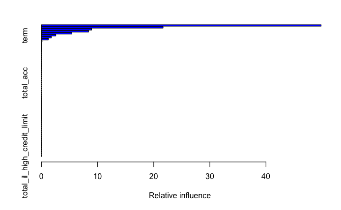

```r
summary(model.gbm)
```

```r
#Prediction
pred.gbm <- predict(object = model.gbm,
                  newdata = Loan_test,
                  n.trees = 1000,
                  type = "response")
head(pred.gbm)
```

```
[1] 0.002085220 0.026692117 0.001976197 0.002214678 0.043876405 0.001751426
```

```r
#Evaluate model performance
#Area under the ROC curve
auc.gbm <- auc(actual = Loan_test$loan_status, predicted = pred.gbm)
sprintf("GBM Test AUC: %.3f", auc.gbm)
```

```
[1] "GBM Test AUC: 0.999"
```

```r
#Converting prediction result to binary class
class.gbm <- ifelse(pred.gbm > 0.5, 1, 0)
class.gbm <- as.factor(class.gbm)
#Confusion matrix
confusionMatrix(data = class.gbm, reference = Loan_test$loan_status)
```

```
Confusion Matrix and Statistics

          Reference
Prediction     0     1
         0 27550   417
         1     0  5605

               Accuracy : 0.9876
                 95% CI : (0.9863, 0.9887)
    No Information Rate : 0.8206
    P-Value [Acc > NIR] : < 2.2e-16

                  Kappa : 0.9566
 Mcnemar's Test P-Value : < 2.2e-16

            Sensitivity : 1.0000
            Specificity : 0.9308
         Pos Pred Value : 0.9851
         Neg Pred Value : 1.0000
             Prevalence : 0.8206
         Detection Rate : 0.8206
   Detection Prevalence : 0.8330
      Balanced Accuracy : 0.9654

       'Positive' Class : 0
```

### Step 4: Comparing model performances

Compute the accuracy and, if appropriate, the area under the ROC curve (AUC) to rank the classification accuracy of each model.

[figure not shown]

```r
sprintf("Logistic Regression Test AUC: %.3f", auc.logit)
```

```
[1] "Logistic Regression Test AUC: 1.000"
```

```r
sprintf("kNN Test AUC: %.3f", auc.knn)
```

```
[1] "kNN Test AUC: 0.213"
```

```r
sprintf("C5.0 Tree Test AUC: %.3f", auc.c50)
```

```
[1] "C5.0 Tree Test AUC: 0.998"
```

```r
sprintf("Naive Bayes Test AUC: %.3f", auc.nb)
```

```
[1] "Naive Bayes Test AUC: 0.903"
```

```r
sprintf("Random Forest Test AUC: %.3f", auc.rf)
```

```
[1] "Random Forest Test AUC: 0.999"
```

```r
sprintf("Bagged Trees Test AUC: %.3f", auc.bagging)
```

```
[1] "Bagged Trees Test AUC: 0.997"
```

```r
sprintf("GBM Test AUC: %.3f", auc.gbm)
```

```
[1] "GBM Test AUC: 0.999"
```

## Bonus

After fitting model and evaluate model performance on test set. Logistic regression with LASSO as a regularization method is the best model. Thus, I apply the same model to classify credit default on 2015 data. Since there are new levels introduced in 2015 dataset that are not in the model, I relevel the categorical variables in the training, refit the model, and then use the model to predict 2015 data.

#### Step 1: Download data

```r
#Unzip data files
unzip("./data/2015.zip",exdir="./data")

#Clean up data directory
fn <- "./data/2015.zip"
if (file.exists(fn)) file.remove(fn)

#Read the.csv files
Loan_15 <- read.csv(file="./data/LoanStats3d.csv", skip = 1, na.strings=c(""))

head(Loan_15)
tail(Loan_15)
```

#### Step 2: Prepare data

```r
#Removing the last two rows, empty rows due to importing error
Loan_15 <- Loan_15[1:(nrow(Loan_15)-2),]

#Get the indices of those loans categorized as Charged Off, Fully Paid, or Default
indx <- which(Loan_15[["loan_status"]] == c("Charged Off", "Fully Paid"))

Loan_15_dropped <- Loan_15[indx,]

#Converting response variable as a factor of binary outcomes
Loan_15_dropped$loan_status <- ifelse(Loan_15_dropped$loan_status == "Fully Paid", 0, 1)
Loan_15_dropped$loan_status <- as.factor(Loan_15_dropped$loan_status)
```

```r
#Subset only columns that are in model
myVector <- colnames(Loan_train)
Loan_15_subset <- Loan_15_dropped[, myVector]

# Remove rows that contains NAs
Loan_15_subset <- na.omit(Loan_15_subset)
```

```r
#Converting interest rate variable to numeric
Loan_15_subset$int_rate <- as.numeric(sub("%","",Loan_15_subset$int_rate))/100
Loan_15_subset$revol_util <- as.numeric(sub("%","",Loan_15_subset$revol_util))/100

#Converting categorical variables
#update new levels
levels(Loan_train$purpose) <- levels(Loan_15_subset$purpose)
#re-level
Loan_train$home_ownership <- factor(Loan_train$home_ownership, levels = c(levels(Loan_train$home_ownership), "ANY"))
levels(Loan_15_subset$home_ownership) <- levels(Loan_train$home_ownership)
```

```r
summary(Loan_15_subset)
```

### Step 3: Prediction on 2015 data

### Logistic regression model

```r
#Turn test data to sparse matrix for same dimension as train data
trainX <- model.matrix(loan_status~., data=Loan_train)[,-1]
trainY <- Loan_train$loan_status
test <- model.matrix(loan_status~., data=Loan_15_subset)[,-1]
testX <- as.matrix(test)
dim(testX)
dim(trainX)

library(glmnet)

#refit model - with new levels
mod.logit <-  glmnet(x=trainX, y=trainY,family="binomial",alpha=1, lambda = 0.001, standardize = FALSE )

#Prediction
pred.logit <- predict(mod.logit, testX, type = 'response')
head(pred.logit)

detach("package:glmnet", unload=TRUE)

library(Metrics)
#Evaluate model performance
#Area under the ROC curve22
auc.logit <- auc(actual = Loan_15_subset$loan_status, predicted = pred.logit)
sprintf("Logistic Regression Test AUC: %.3f", auc.logit)

#Converting prediction result to binary class
class.logit <- ifelse(pred.logit > 0.5, 1, 0)
class.logit <- as.factor(class.logit)

library(caret)
confusionMatrix(data = class.logit, reference = Loan_15_subset$loan_status)
```

[output not shown]